# Applicant Insights Report - Descriptive Analytics

Isaac B. Michael

September 17, 2025

# 1. Introduction

**Years analyzed:** 2022–present

The purpose of this report is to:

- **Understand** who is applying and enrolling
- **Track** trends year over year
- **Identify** key markets and referral sources to guide **future outreach and advertising**

## 1.1 Data Sources

This report combines both **internal program data** (applicant spreadsheets) and **external contextual data** (school directories and Census data).

### 1.1.1 Internal Sources

Applicant spreadsheets submitted via registration (**Excel format**). The following annual applicant files are below:

```
## [1] "applicants_2022.xlsx" "applicants_2023.xlsx" "applicants_2024.xlsx"
## [4] "applicants_2025.xlsx"
```

Each year, new annual files (e.g. `applicants_2027.xlsx`) will be added to the same folder. This report will **use all available years** and update the results when re-knit.

### 1.1.2 External Sources

NCES Common Core of Data (CCD) – Public/Charter School Directory  
- **Source:** [NCES CCD](https://nces.ed.gov/ccd/pubschuniv.asp)  
- **Example file used:** `ccd1819.csv`

NCES Private School Survey (PSS) – Private School Directory  
- **Source:** [NCES PSS](https://nces.ed.gov/surveys/pss/)  
- **Example file used:** `pss2122.csv`

U.S. Census Bureau, American Community Survey (ACS) – Median Household Income by ZIP Code Tabulation Area (Table B19013)  
- **Source:** [data.census.gov](https://data.census.gov/)  
- **Example file used:** `acs22.csv`

# 2. Data Preparation

In this section, we detail the steps taken to clean, harmonize, and enrich the raw applicant data in preparation for analysis.

Processes included consolidating internal application files, joining external datasets (NCES school directories, ACS income data), normalizing variables, and applying quality checks to ensure consistency.

## 2.1 Overview

We begin by summarizing the size of each applicant dataset (number of observations and variables).

Observations and Variables per Year

| year | file | observations | variables |
| --- | --- | --- | --- |
| 2022 | applicants_2022.xlsx | 22 | 48 |
| 2023 | applicants_2023.xlsx | 22 | 61 |
| 2024 | applicants_2024.xlsx | 28 | 63 |
| 2025 | applicants_2025.xlsx | 44 | 63 |

## 2.2 Variable Comparison by Year

This will show you if the same variables exist consistently or if some need renaming.

|  | variable | in_2022 | in_2023 | in_2024 | in_2025 |
| --- | --- | --- | --- | --- | --- |
| 1 | additional_parent_or_guardian_e_mail | False | True | True | True |
| 2 | additional_parent_or_guardian_name_first | False | True | True | True |
| 3 | additional_parent_or_guardian_name_last | False | True | True | True |
| 4 | additional_parent_or_guardian_phone_number | False | True | True | True |
| 5 | address_address | True | False | False | False |
| 6 | address_address2 | True | False | False | False |
| 7 | address_city | True | False | False | False |
| 8 | address_country | True | False | False | False |
| 9 | address_state | True | False | False | False |
| 10 | address_zip | True | False | False | False |

[output cut: 94 more lines]

## 2.3 Standardize Data

To ensure consistency across multiple application years, we performed a set of cleaning and harmonization steps before analysis.

- **Name and Location Fields**: Student names, home cities, and school cities were converted to title case for readability. State values were normalized so that both full state names and abbreviations map to standard USPS two-letter codes (e.g., “Georgia” → “GA”). Extra whitespace was trimmed throughout.
- **Cross-Year Schema Alignment**: Application forms used different column names in different years (e.g., “student_email_address” vs. “student_e_mail_address”). We mapped these variations into a unified schema that includes email, phone, demographics, home/school address, grade, referral source, needs-based aid, payment, and completion status.
- **Session and Financial Aid**: Free-text session choices were standardized into Session 1 or Session 2. Financial need was captured from either a written explanation or uploaded documentation, producing a unified `needs_based` flag.
- **Payments**: Payment fields were cleaned, tuition values joined by year, and a boolean `paid` flag was derived based on payment status text and amounts.

The result is a combined dataset (`apps_all`) covering all application years, and a streamlined analysis dataset (`apps_core`) containing harmonized identifiers, demographics, addresses, school details, referral sources, financial aid, payments, and program outcomes.

**Note:** Detailed cleaning code is omitted here for readability.

## 2.4 Duplicate Check

We check for and remove duplicate records using the following rules:

- We de-dupe **within each year** (cross-year repeats are returning students and are kept).
- Prefer the record that looks “most complete / most paid”.
- Primary key is **email** (lowercased/trimmed); if that’s missing, fall back to **name + DOB**.

De-duplication summary (within year + session)

| year | session | n_before | n_after | removed |
| --- | --- | --- | --- | --- |
| 2022 | 1 | 11 | 11 | 0 |
| 2022 | 2 | 11 | 11 | 0 |
| 2023 | 1 | 10 | 10 | 0 |
| 2023 | 2 | 12 | 12 | 0 |
| 2024 | 1 | 12 | 12 | 0 |
| 2024 | 2 | 16 | 16 | 0 |
| 2025 | 1 | 14 | 14 | 0 |
| 2025 | 2 | 30 | 30 | 0 |

## 2.5 School Classification

In order to better understand the types of schools our applicants are coming from, we classified each student’s school as **Public, Private, or Charter**.

This provides important context for evaluating outreach effectiveness and access across different school types.

### 2.5.1 CCD and PSS Data

We enhance the dataset by **classifying schools** using the NCES directories:

- **Public schools** → NCES *Common Core of Data (CCD)*
- **Private schools** → NCES *Private School Survey (PSS)*

**Process:**

1. Clean column names and extract a consistent set of fields:
   - `school_name`
   - `school_city`
   - `school_state`
   - `school_zip`
   - `nces_type`
2. Combine CCD and PSS into a **unified lookup table**: `nces_schools`.
3. Join this lookup table with our applicant dataset (`apps_core_nodup`) to assign a new variable: `school_type`.

**Classification rules:**

- `"Public"` → if a CCD match is found
- `"Private"` → if a PSS match is found
- `"Charter"` → if detected in NCES data or keywords in name
- `"Private"` (fallback) → if keywords like *“Prep”*, *“Academy”*, *“Independent”* are found
- `"N/A"` → if no match or keyword detected

NCES match breakdown (after progressive and fuzzy matching)

| match_level | n | pct |
| --- | --- | --- |
| fuzzy(name)+state | 2 | 1.72% |
| name+city+state | 1 | 0.86% |
| name+city+state+zip | 8 | 6.90% |
| name+state | 5 | 4.31% |
| no_match | 100 | 86.21% |

### 2.5.2 Heuristics

Because of this low direct match rate, we applied **keyword-based heuristics** as a fallback to classify unmatched schools.

For example:

- Names containing **“Academy”** or **“Prep”** → *Private*
- Names containing **“High School”** or **“Public”** → *Public*
- Names containing **“Charter”** → *Charter*

The final distribution of school types, after applying both NCES data and heuristics, is shown below:

Final School Type Classification (NCES + heuristics)

| school_type | n | pct |
| --- | --- | --- |
| Public | 57 | 49.1% |
| N/A | 48 | 41.4% |
| Private | 8 | 6.9% |
| Charter | 3 | 2.6% |

## 2.6 ZIP Code Socioeconomics

To better understand the socioeconomic background of applicants, we enrich the dataset by linking each student’s home ZIP code to publicly available Census Bureau data.

Specifically, we use the **American Community Survey (ACS) 5-Year Estimates (2018–2022 release)**, Table **B19013**: *Median Household Income in the Past 12 Months*. The ACS 5-year dataset is chosen because it provides **stable, reliable estimates at small geographies** such as ZIP Code Tabulation Areas (ZCTAs), whereas 1-year estimates are not consistently available at the ZIP level and can be noisy due to small samples.

**Steps:**

- Normalize all student ZIP codes into standard 5-digit format.
- Join the applicant dataset with ACS median household income by ZCTA.
- Compute national quartiles of median ZIP incomes from ACS data.
- Categorize students into **socioeconomic tiers** based on the ZIP where they live:
  - **Low Income** → bottom 25% of ZIP codes
  - **Middle Income** → 25th–75th percentile ZIP codes
  - **High Income** → top 25% of ZIP codes
- If no ACS match is found, the SES value is set to **Unknown**.

**Important Notes:**

- This method classifies students by the **median income of their ZIP code area**, not by their individual household income. It should therefore be interpreted as a **proxy for neighborhood-level socioeconomic context**, not a precise measure of family resources.
- Percentile thresholds (25th = $53,464; 75th = $85,184) are based on the ACS 2018–2022 distribution and may differ from **national household income percentiles reported in CPS** surveys.
- As new ACS 5-year releases become available (e.g., 2019–2023), these benchmarks should be updated to reflect changes in the national income distribution.

| Category | Income_Range |
| --- | --- |
| Low Income | ≤ $53,464 |
| Middle Income | $53,464 – $85,184 |
| High Income | ≥ $85,184 |

| ses_label | n |
| --- | --- |
| High Income | 84 |
| Low Income | 5 |
| Middle Income | 20 |
| N/A | 7 |

## 2.7 Final Analytic Dataset

Below is a preview of the **final cleaned analytic dataset**, `apps_core_nodup`, which now includes:

- Harmonized variables across years
- De-duplicated student records
- Completion status (`completed_program`)
- School type (Public / Private / Charter / Unknown)
- Socioeconomic status (`ses_label`) derived from ZIP → Census income

The final analytic dataset contains **116** student records after cleaning and de-duplication.

|  | year | tuition | gender_unified | race_ethnicity | grade | home_state | school_type | session | needs_based | paid | completed_program | median_income | ses_label |
| --- | --- | --- | --- | --- | --- | --- | --- | --- | --- | --- | --- | --- | --- |
| 1 | 2022 | $895 | Male | Asian | 9 | CA | N/A | 1 | False | True | Yes | $199,042 | High Income |
| 2 | 2022 | $895 | Female | Asian | 8 | VA | N/A | 1 | False | True | Yes | $149,420 | High Income |
| 3 | 2022 | $895 | Male | Asian | 8 | MN | N/A | 1 | False | True | Yes | $122,785 | High Income |
| 4 | 2022 | $895 | Male | Asian | 10 | MA | N/A | 1 | False | True | Yes | $86,335 | High Income |
| 5 | 2022 | $895 | Male | Asian | 10 | CA | N/A | 1 | False | True | Yes | $151,500 | High Income |
| 6 | 2022 | $895 | Female | Asian | 10 | LA | N/A | 1 | False | True | Yes | $43,884 | Low Income |
| 7 | 2022 | $895 | Male | Asian | 10 | CA | N/A | 1 | False | True | Yes | $202,775 | High Income |
| 8 | 2022 | $895 | Male | Prefer not to answer | 11 | MN | N/A | 1 | False | True | Yes | $115,704 | High Income |
| 9 | 2022 | $895 | Male | Asian | 8 | AZ | N/A | 1 | False |  | No | $114,480 | High Income |
| 10 | 2022 | $895 | Male | Asian | 9 | LA | N/A | 1 | False | True | Yes | $57,746 | Middle Income |

[output cut: 106 more lines]

# 3. Exploratory Data Analysis

Now that we have prepared and harmonized the applicant data, we move into the exploratory analysis phase.  
The primary goal of this section is to **better understand who our applicants are and what factors influence participation** in the program.

Specifically, we want to answer questions such as:

Throughout this section, we will use **data visualizations** (bar charts, pie charts, histograms, maps, and line graphs) to highlight patterns and trends.

These insights will help us identify which groups we are serving well, where we may need targeted outreach, and how to design recruitment strategies that will bring more students into the program.

All analyses in this chapter are based on the final analytic dataset (**n = 116**).

## 3.1 Geographic Distribution

One of the first questions we want to explore is: **Where are our applicants coming from?**

Understanding the geographic spread of students can help us:

- Identify regions that are consistently sending applicants (strong recruitment areas).
- Detect underserved regions where we could increase outreach.
- Examine whether applicants are concentrated in a few states or broadly distributed.
- Compare U.S. vs. international applicants.

We use the cleaned `home_city`, `home_state`, and `home_zip` variables to summarize locations. For visualization, we include:

- A **state-level bar chart** showing counts of applicants by state.
- A **U.S. map** highlighting geographic concentrations of applicants.
- A **table of top cities/ZIP codes** by applicant count.

### 3.1.1 Top States by Count

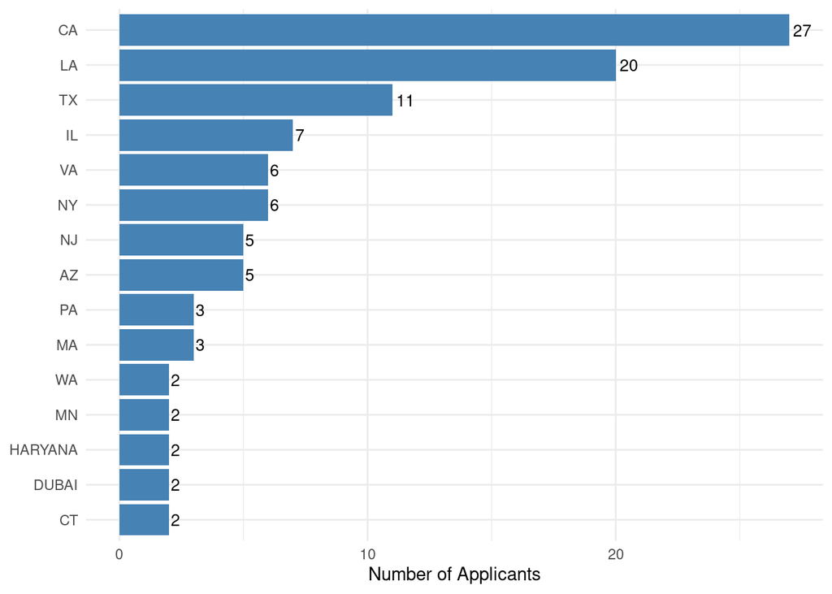

### 3.1.2 U.S. Map Distribution

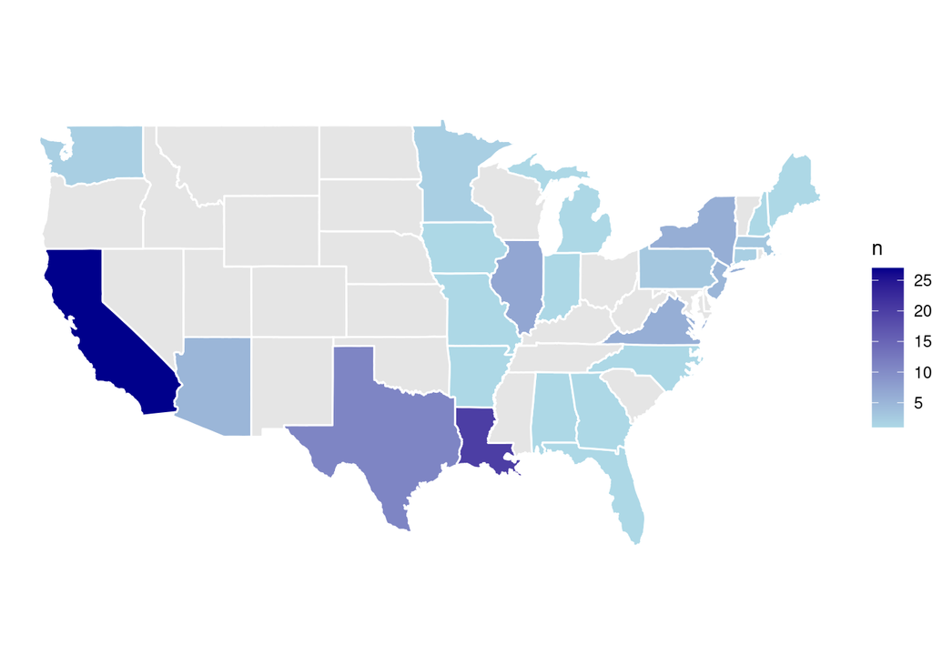

### 3.1.3 Top Cities by Count

|  | home_city | home_state | n |
| --- | --- | --- | --- |
| 1 | Baton Rouge | LA | 8 |
| 2 | Dublin | CA | 4 |
| 3 | Mclean | VA | 4 |
| 4 | San Jose | CA | 4 |
| 5 | Western Springs | IL | 4 |
| 6 | Austin | TX | 3 |
| 7 | New Orleans | LA | 3 |
| 8 | New York | NY | 3 |
| 9 | Bellevue | WA | 2 |
| 10 | Dubai | DUBAI | 2 |

[output cut: 6 more lines]

## 3.2 Demographic Profiles

To better understand the applicant pool, we examine **demographic characteristics** such as:

- **Gender** distribution
- **Race/Ethnicity** composition

These insights can help us assess:

- Whether the program is reaching applicants across different groups.
- If there are demographic segments that could be targeted more effectively.

We visualize this data with bar charts and pie charts for clarity.

### 3.2.1 Gender Distribution

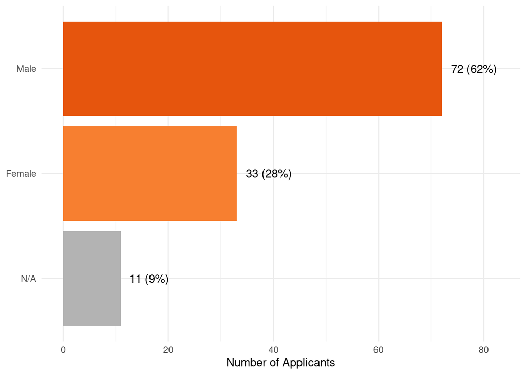

### 3.2.2 Race/Ethnicity Distribution

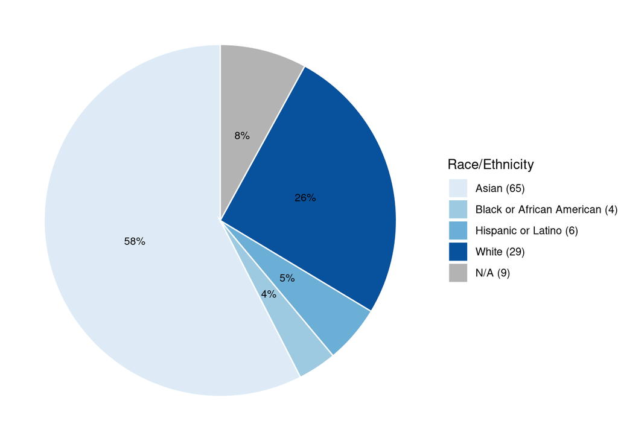

## 3.3 Academic Profiles

Beyond demographics, understanding the **academic background** of applicants helps us identify whether the program is reaching the intended student population and where there may be opportunities to expand access.

Specifically, we examine:

- **Grade level distribution**: Which grades are most represented? Are we attracting middle school, early high school, or upper high school students?
- **Age distribution**: Using reported dates of birth, how old are our applicants at the time of application?
- **School type (Public, Private, Charter, Unknown)**: Using NCES matching and keyword heuristics, we classify schools to better understand whether applicants are coming from public or private educational settings.

This information allows us to evaluate whether the program is effectively engaging its **target age groups** and to detect any over- or under-representation of certain grade levels or school types.

These insights can directly inform outreach efforts — for example, tailoring recruitment to specific grades or balancing outreach between public and private schools.

### 3.3.1 Grade Distribution

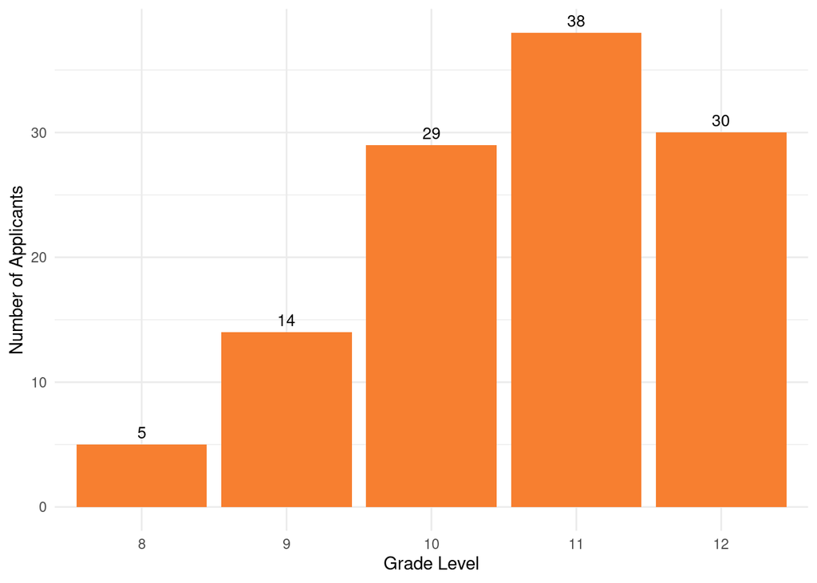

### 3.3.2 Age Distribution (10-25 yrs)

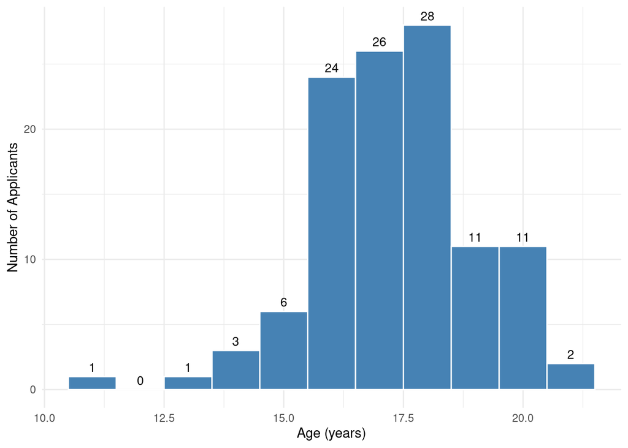

### 3.3.3 School Type Distribution

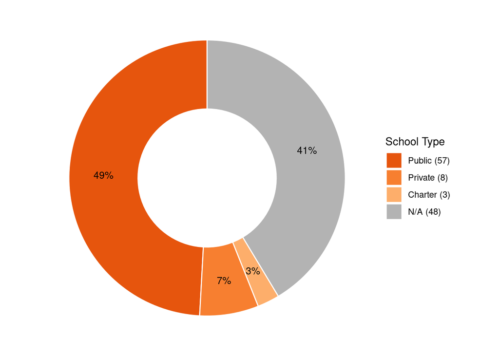

## 3.4 Socioeconomic Status (SES)

Socioeconomic background can significantly influence program participation and access to enrichment opportunities.

Because individual household income data were not collected from applicants, we estimated SES using U.S. Census Bureau **ACS 2018–2022 5-Year Estimates** (Table **B19013: Median Household Income in the Past 12 Months**) at the **ZIP Code Tabulation Area (ZCTA)** level.

Each applicant’s ZIP code was linked to the **median household income** of their ZCTA. Applicants were then assigned to **income tiers** based on the national distribution of ZIP code medians (not individual household income):

- **Low Income (≤ $53,464)** → bottom 25% of ZIP codes
- **Middle Income ($53,464–$85,184)** → 25th–75th percentile ZIP codes
- **High Income (≥ $85,184)** → top 25% of ZIP codes
- **Unknown** → ZIP code missing or not matched

These tiers provide a *ZIP-level proxy* for socioeconomic status, offering useful—though indirect—insight into applicants’ likely income backgrounds. This approach highlights whether the program is disproportionately serving students from higher-income communities, or if outreach is reaching a more diverse socioeconomic spectrum.

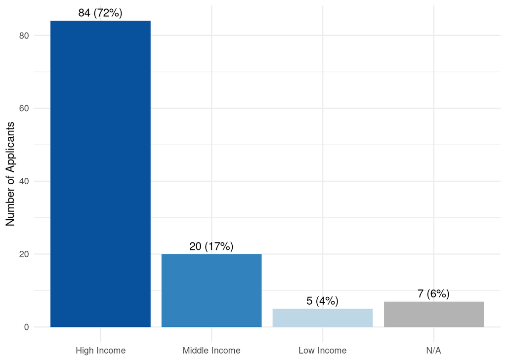

## 3.5 Program Completion Rates

A central measure of success for the summer program is whether students **complete** the program after registering. By analyzing completion rates, we can identify areas where additional support, mentoring, or outreach may be needed.

Key questions we aim to answer:

- What proportion of applicants successfully completed the program?
- Are there differences in completion rates across **gender, race/ethnicity, SES, or state**?

### 3.5.1 Overall Rate

| completed_program | n | pct |
| --- | --- | --- |
| No | 16 | 13.8 |
| Yes | 100 | 86.2 |

### 3.5.2 By Gender

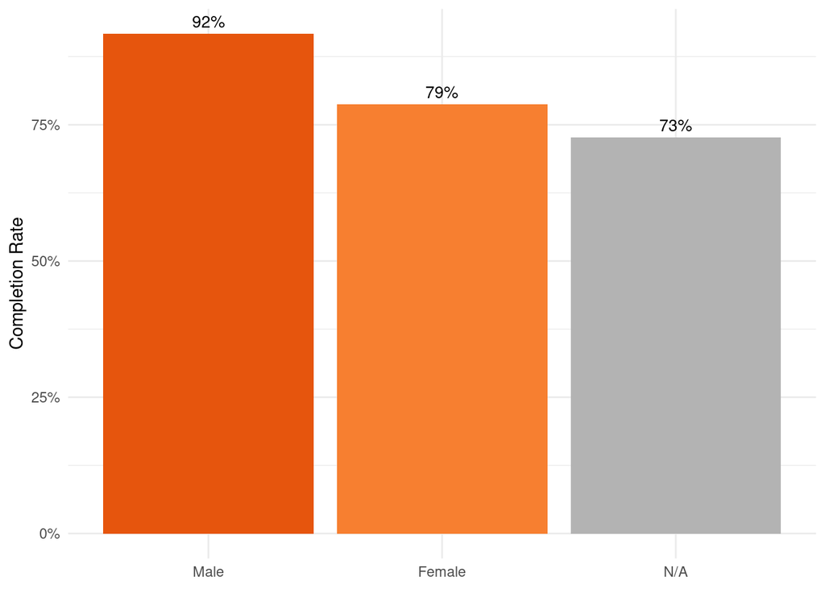

### 3.5.3 By Race/Ethnicity

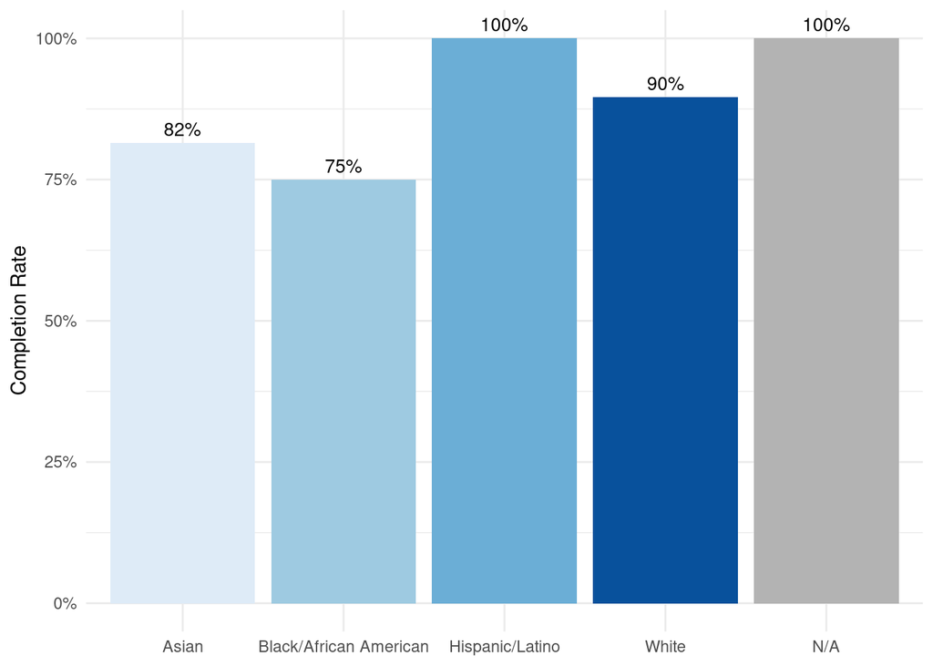

### 3.5.4 By State

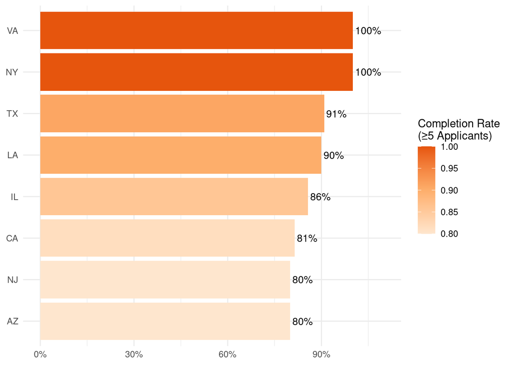

### 3.5.5 By Socioeconomic Status

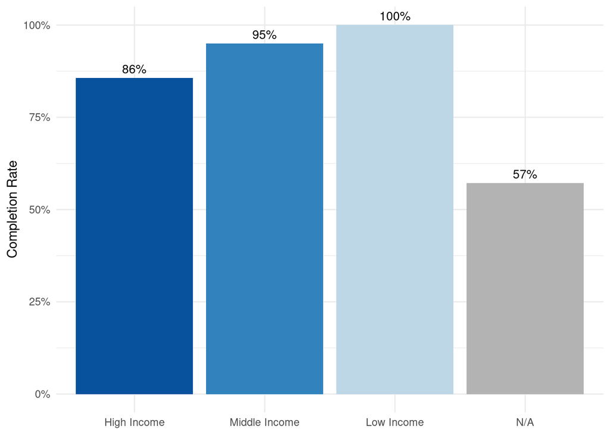

## 3.6 Trend Analysis

Understanding how applicant/completion numbers and program completion rates change over time helps us evaluate the growth and effectiveness of the STEM program.

By analyzing year-over-year trends, we can assess:

- Whether marketing and outreach efforts are increasing applicant volume.
- If completion rates are stable, improving, or declining across years.
- Whether certain years show anomalies (e.g., spikes or drops) that warrant closer review.

This analysis provides actionable insight into the **long-term sustainability** and **impact** of the program.

### 3.6.1 Counts by Year

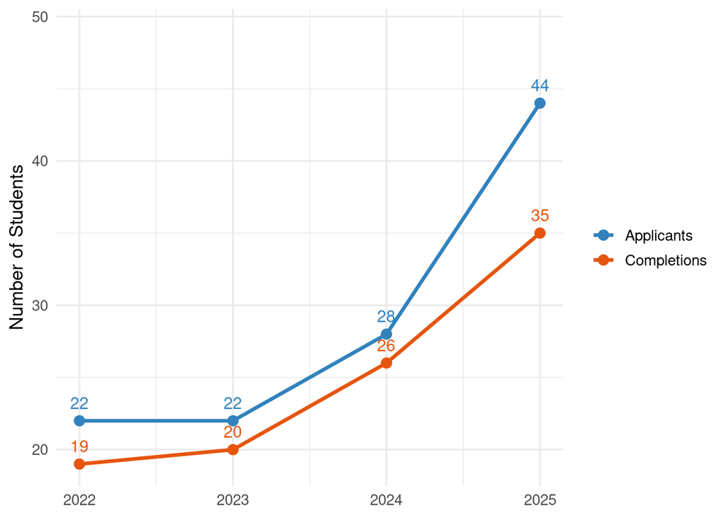

### 3.6.2 Completion Rates by Year

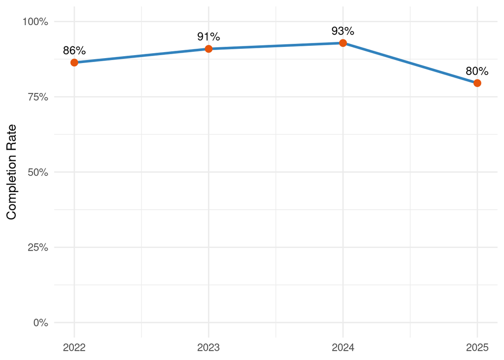

# 4. Conclusion

The analyses in Section 3 provide a comprehensive look at applicant demographics, academic background, socioeconomic distribution, and program outcomes. Together, these findings highlight both the program’s strengths and areas for improvement.

## 4.2 Recommendations

- **Expand Geographic Advertising**: Increase outreach and digital ad placement in **Midwestern and underrepresented states** to broaden applicant diversity.
- **Expand Access**: Strengthen recruitment efforts in **lower-income schools and districts**, and more clearly emphasize **needs-based fee reductions** to reduce financial barriers.
- **Broaden Recruitment**: Partner with community organizations and affinity groups to **increase Black and Hispanic/Latino participation**, including mentorship and referral initiatives.
- **Leverage Referral & School Channels**: Scale up existing effective strategies (e.g., **teacher networks, flyers, student/mentor ambassador programs**) to maintain growth.
- **Improve Data Capture & Matching**: Standardize **school names, ZIP codes, and demographic fields** at registration to improve accuracy of SES and school classification data.
- **Monitor Completion Gaps**: Continue tracking completion by **year, SES, gender, and race/ethnicity**, and pilot targeted support for groups with lower retention rates.